# Comparative Analysis of Model Performance for Coffee Discrimination Using Hyperspectral Imaging and Machine Learning: Impact of Preprocessing and Variable Selection

### Perform Kruskall-Wallis Test for Variable Selection

#### Imbalanced Data Set - Kruskall-Wallis Test

```r
kruskal.test(Unbalanced_Data_MCC~Wav_Selec_Reduction, data= df)
```

```
    Kruskal-Wallis rank sum test

data:  Unbalanced_Data_MCC by Wav_Selec_Reduction
Kruskal-Wallis chi-squared = 0.69555, df = 2, p-value = 0.7063
```

```r
kruskal.test(Balanced_Data_MCC~Wav_Selec_Reduction, data= df)
```

```
    Kruskal-Wallis rank sum test

data:  Balanced_Data_MCC by Wav_Selec_Reduction
Kruskal-Wallis chi-squared = 0.48529, df = 2, p-value = 0.7845
```

- There is no statistically significant difference in model performance based on variable selection methods (p > 0.05). This indicates that these techniques effectively identify variables or regions with useful information without compromising model performance. This will, however, be investigated further by General Linear Model (GLM).

## Check Performance based on spectral preprocessing methods

- The hyperspectral imaging spectra were pre-processed using various techniques, including Standard Normal Variate (SNV) and Multiplicative Scatter Correction (MSC), combined with Savitzky-Golay filtering and derivatives. Unprocessed spectra were used as the baseline for comparison.

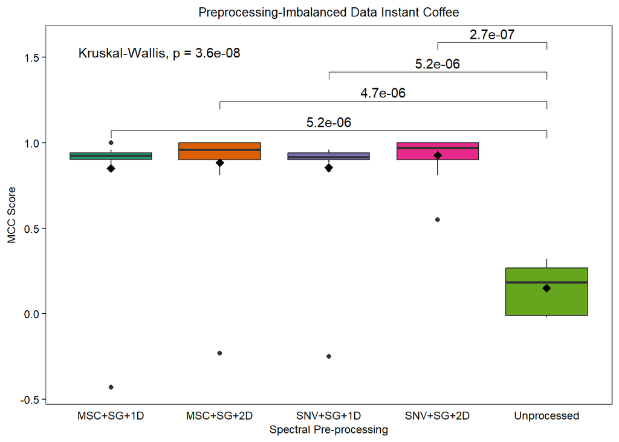

```r
# Visualize with box plots

# Imbalanced Data
my_comparisons <- list(
  c('MSC+SG+1D', 'Unprocessed'),
  c('MSC+SG+2D', 'Unprocessed'),
  c('SNV+SG+1D', 'Unprocessed'),
  c('SNV+SG+2D', 'Unprocessed')
)

df %>% ggplot(aes(x = Pre_processing, y = Unbalanced_Data_MCC))+
  geom_boxplot(aes(fill = Pre_processing))+
  labs(title = 'Preprocessing-Imbalanced Data Instant Coffee',x = 'Spectral Pre-processing')+
  ylab('MCC Score')+
  theme_bw()+
  theme(
    axis.title.x = element_text(color = "black", size = 9),
    axis.text.x = element_text(color = "black", size = 9),
    axis.ticks.x = element_blank(),
    axis.text.y = element_text(color = "black", size = 9),
    axis.title.y = element_text(color = "black", size = 9),
    plot.title = element_text(hjust = 0.5, color = 'black', size = 10),
    panel.grid = element_blank(),
    legend.position = 'none')+
  scale_fill_brewer(palette = "Dark2", name = 'Preprocessing')+
  stat_summary(fun=mean, geom="point", shape=18, size=3, color="black")+
  stat_compare_means(comparisons = my_comparisons)+
  stat_compare_means(method = 'kruskal.test', label.y = max(df$Unbalanced_Data_MCC) * 1.5)
```

```r
ggsave("MCC_Imbalanced_Data_Preprocessing.png", width = 6, height = 4, dpi = 600, bg = "white")
```

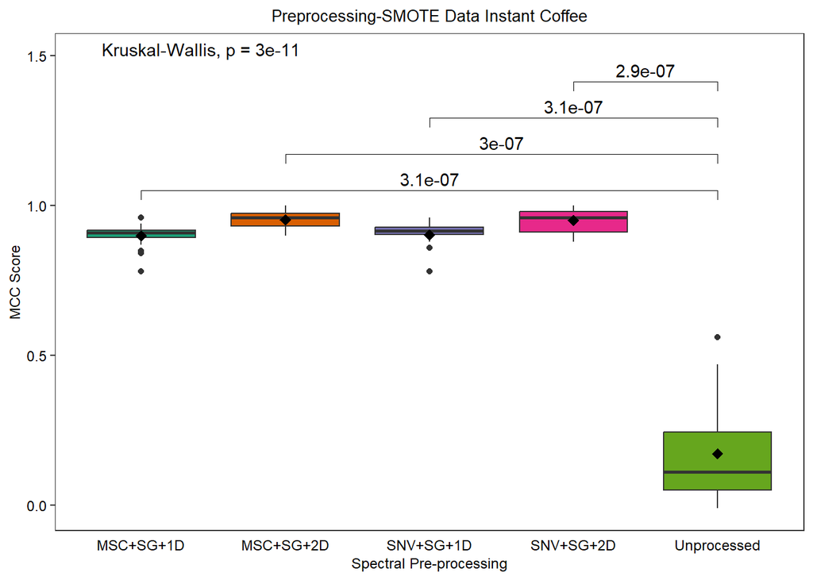

```r
# Visualize with box plots
my_comparisons <- list(
  c('MSC+SG+1D', 'Unprocessed'),
  c('MSC+SG+2D', 'Unprocessed'),
  c('SNV+SG+1D', 'Unprocessed'),
  c('SNV+SG+2D', 'Unprocessed')
)

df %>% ggplot(aes(x = Pre_processing, y = Balanced_Data_MCC))+
  geom_boxplot(aes(fill = Pre_processing))+
  labs(title = 'Preprocessing-SMOTE Data Instant Coffee', x = 'Spectral Pre-processing')+
  ylab('MCC Score')+
  theme_bw()+
  theme(
    axis.title.x = element_text(color = "black", size = 9),
    axis.text.x = element_text(color = "black", size = 9),
    axis.ticks.x = element_blank(),
    axis.text.y = element_text(color = "black", size = 9),
    axis.title.y = element_text(color = "black", size = 9),
    plot.title = element_text(hjust = 0.5, color = 'black', size = 10),
    panel.grid = element_blank(),
    legend.position = 'none')+
  scale_fill_brewer(palette = "Dark2", name = 'Preprocessing')+
  stat_summary(fun=mean, geom="point", shape=18, size=3, color="black")+
  stat_compare_means(comparisons = my_comparisons)+
  stat_compare_means(label.y = max(df$Unbalanced_Data_MCC) * 1.5)
```

```r
ggsave("MCC_SMOTE_Data_Preprocessing.png", width = 6, height = 4, dpi = 600, bg = "white")
```

### Perform Kruskall-Wallis Test for Spectral Preprocessing Techniques

#### Imbalanced Data Set - Kruskall-Wallis Test

```r
kruskal.test(Unbalanced_Data_MCC~Pre_processing, data= df)
```

```
    Kruskal-Wallis rank sum test

data:  Unbalanced_Data_MCC by Pre_processing
Kruskal-Wallis chi-squared = 40.4, df = 4, p-value = 3.577e-08
```

#### Balanced Data Set - Kruskall-Wallis Test

```r
kruskal.test(Balanced_Data_MCC~Pre_processing, data= df)
```

```
    Kruskal-Wallis rank sum test

data:  Balanced_Data_MCC by Pre_processing
Kruskal-Wallis chi-squared = 55.167, df = 4, p-value = 2.998e-11
```

- Spectral preprocessing significantly (p < 0.05) influences the performance of models.

#### Checking for differences in pre-processing techniques for Unbalanced Data

```r
dunn.test(df$Unbalanced_Data_MCC, df$Pre_processing, method = 'bonferroni')
```

```
  Kruskal-Wallis rank sum test

data: x and group
Kruskal-Wallis chi-squared = 40.4003, df = 4, p-value = 0

                           Comparison of x by group
                                 (Bonferroni)
Col Mean-|
Row Mean |   MSC+SG+1   MSC+SG+2   SNV+SG+1   SNV+SG+2
---------+--------------------------------------------
MSC+SG+2 |  -1.270096
         |     1.0000
SNV+SG+1 |   0.179609   1.449706
         |     1.0000     0.7357
SNV+SG+2 |  -1.398389  -0.128292  -1.577998
         |     0.8100     1.0000     0.5728
Unproces |   4.140643   5.410739   3.961033   5.539032
         |    0.0002*    0.0000*    0.0004*    0.0000*

alpha = 0.05
Reject Ho if p <= alpha/2
```

#### Checking for differences in pre-processing techniques for Balanced Data

```r
dunn.test(df$Balanced_Data_MCC, df$Pre_processing, method = 'bonferroni')
```

```
  Kruskal-Wallis rank sum test

data: x and group
Kruskal-Wallis chi-squared = 55.167, df = 4, p-value = 0

                           Comparison of x by group
                                 (Bonferroni)
Col Mean-|
Row Mean |   MSC+SG+1   MSC+SG+2   SNV+SG+1   SNV+SG+2
---------+--------------------------------------------
MSC+SG+2 |  -2.721606
         |     0.0325
SNV+SG+1 |  -0.512905   2.208700
         |     1.0000     0.1360
SNV+SG+2 |  -2.638259   0.083347  -2.125353
         |     0.0417     1.0000     0.1678
Unproces |   3.724978   6.446584   4.237883   6.363237
         |    0.0010*    0.0000*    0.0001*    0.0000*

alpha = 0.05
Reject Ho if p <= alpha/2
```

- Models trained on spectra pre-processed using SNV+SG+1st derivative, SNV+SG+2nd derivative, MSC+SG+1st derivative, and MSC+SG+2nd derivative significantly outperformed those trained on raw, unprocessed spectra.

### Does training on either imbalanced or Balanced Data set affect model performance?

We will use Mann-Whitney U Test to check for differences in performance based on MCC and balanced accuracy.

```r
df_bal <- read_excel('summary_model_results_classification_Instant _coffee.xlsx', sheet='data_balance')
df_bal$data_balance <- as.factor(df_bal$data_balance)
df_bal$Model <- as.factor(df_bal$Model)
df_bal$Preprocessing<- as.factor(df_bal$Preprocessing)
```

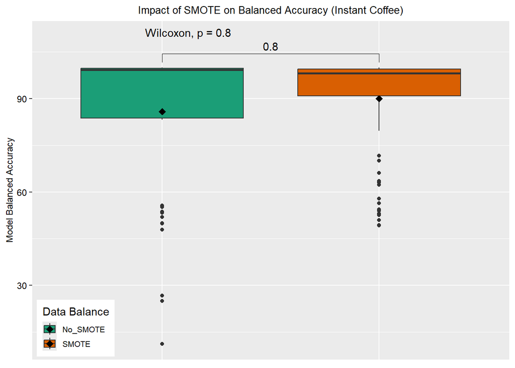

```r
# Define statistical comparisons
my_comparisons <- list(c( "SMOTE","No_SMOTE"))

# Create Boxplot

df_bal %>% ggplot(aes(x = data_balance, y = Balanced_Accuracy, fill = data_balance)) +
  geom_boxplot() +
  labs(title = "Impact of SMOTE on Balanced Accuracy (Instant Coffee)",
       y = "Model Balanced Accuracy")+
 theme(
    axis.title.x = element_blank(),
    axis.text.x = element_blank(),
    axis.ticks.x = element_blank(),
    axis.text.y = element_text(color = "black", size = 9),
    axis.title.y = element_text(color = "black", size = 9),
    plot.title = element_text(hjust = 0.5, color = 'black', size = 10),
    legend.position = c(0.01, 0.009),
    legend.justification = c(0, 0),
    legend.backInstant = element_rect(fill = "white", color = "black"),
    legend.key.size = unit(0.5, "cm"),
    legend.text = element_text(size = 8)
  )+
  scale_fill_brewer(palette = "Dark2", name = 'Data Balance')+
  stat_summary(fun=mean, geom="point", shape=18, size=3, color="black")+
  stat_compare_means(comparisons = my_comparisons)+
  stat_compare_means(label.y = max(df_bal$Balanced_Accuracy) * 1.1)
```

```r
ggsave("SMOTE_Data_Balance_Instant_Coffee.png", width = 6, height = 4, dpi = 600, bg = "white")
```

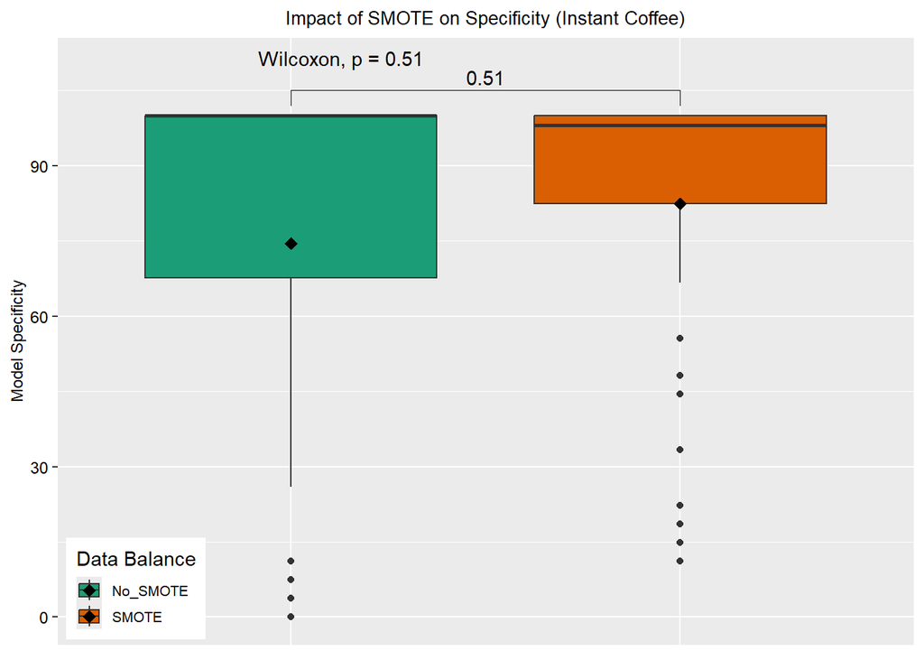

```r
# Define statistical comparisons
my_comparisons <- list(c("No_SMOTE", "SMOTE"))

# Create Boxplot

df_bal %>% ggplot(aes(x = data_balance, y = Specificity, fill = data_balance)) +
  geom_boxplot() +
  labs(title = "Impact of SMOTE on Specificity (Instant Coffee)",
       y = "Model Specificity")+
 theme(
    axis.title.x = element_blank(),
    axis.text.x = element_blank(),
    axis.ticks.x = element_blank(),
    axis.text.y = element_text(color = "black", size = 9),
    axis.title.y = element_text(color = "black", size = 9),
    plot.title = element_text(hjust = 0.5, color = 'black', size = 10),
    legend.position = c(0.01, 0.009),
    legend.justification = c(0, 0),
    legend.backInstant = element_rect(fill = "white", color = "black"),
    legend.key.size = unit(0.5, "cm"),
    legend.text = element_text(size = 8)
  )+
  scale_fill_brewer(palette = "Dark2", name = 'Data Balance')+
  stat_summary(fun=mean, geom="point", shape=18, size=3, color="black")+
  stat_compare_means(comparisons = my_comparisons)+
  stat_compare_means(label.y = max(df_bal$Balanced_Accuracy) * 1.1)
```

```r
#ggsave("SMOTE_Data_Balance_Instant_Coffee.png", width = 6, height = 4, dpi = 600, bg = "white")
```

```r
# Mean for specifity
spec_smote <- df_bal$Specificity[df_bal$data_balance=='SMOTE']
mean(spec_smote)
```

```
[1] 82.42444
```

```r
spec_no_smote <- df_bal$Specificity[df_bal$data_balance=='No_SMOTE']
mean(spec_no_smote)
```

```
[1] 74.52556
```

#### Check model performance with and without SMOTE

```r
# SVM Model
svm <- df_bal %>%
  filter(Model %in% c('SVM_No_SMOTE', 'SVM_SMOTE')) %>%
  dplyr::select(Model, MCC, Balanced_Accuracy, Specificity)
head(svm)
```

```
# A tibble: 6 × 4
  Model          MCC Balanced_Accuracy Specificity
  <fct>        <dbl>             <dbl>       <dbl>
1 SVM_No_SMOTE  0.19              51.9         3.7
2 SVM_No_SMOTE  0.88              94.1        88.9
3 SVM_No_SMOTE  0.81              83.3        66.7
4 SVM_No_SMOTE  0.94              97.9        96.2
5 SVM_No_SMOTE  0.83              85.2        70.3
6 SVM_No_SMOTE -0.02              47.9        25.9
```

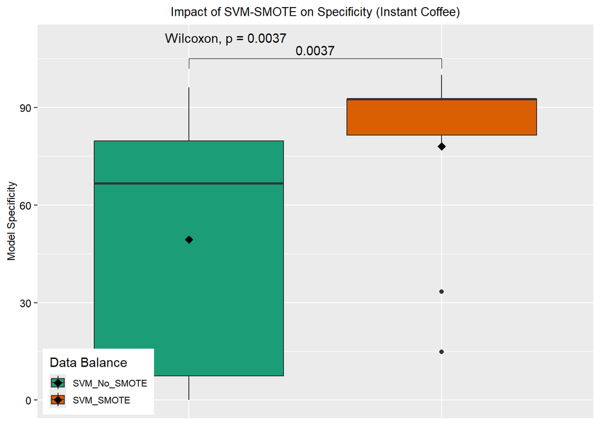

```r
# Define statistical comparisons
my_comparisons <- list(c('SVM_No_SMOTE', 'SVM_SMOTE'))

# Create Boxplot

svm %>% ggplot(aes(x = Model, y = Specificity, fill = Model)) +
  geom_boxplot() +
  labs(title = "Impact of SVM-SMOTE on Specificity (Instant Coffee)",
       y = "Model Specificity")+
 theme(
    axis.title.x = element_blank(),
    axis.text.x = element_blank(),
    axis.ticks.x = element_blank(),
    axis.text.y = element_text(color = "black", size = 9),
    axis.title.y = element_text(color = "black", size = 9),
    plot.title = element_text(hjust = 0.5, color = 'black', size = 10),
    legend.position = c(0.01, 0.009),
    legend.justification = c(0, 0),
    legend.backInstant = element_rect(fill = "white", color = "black"),
    legend.key.size = unit(0.5, "cm"),
    legend.text = element_text(size = 8)
  )+
  scale_fill_brewer(palette = "Dark2", name = 'Data Balance')+
  stat_summary(fun=mean, geom="point", shape=18, size=3, color="black")+
  stat_compare_means(comparisons = my_comparisons)+
  stat_compare_means(label.y = max(df_bal$Specificity) * 1.1)
```

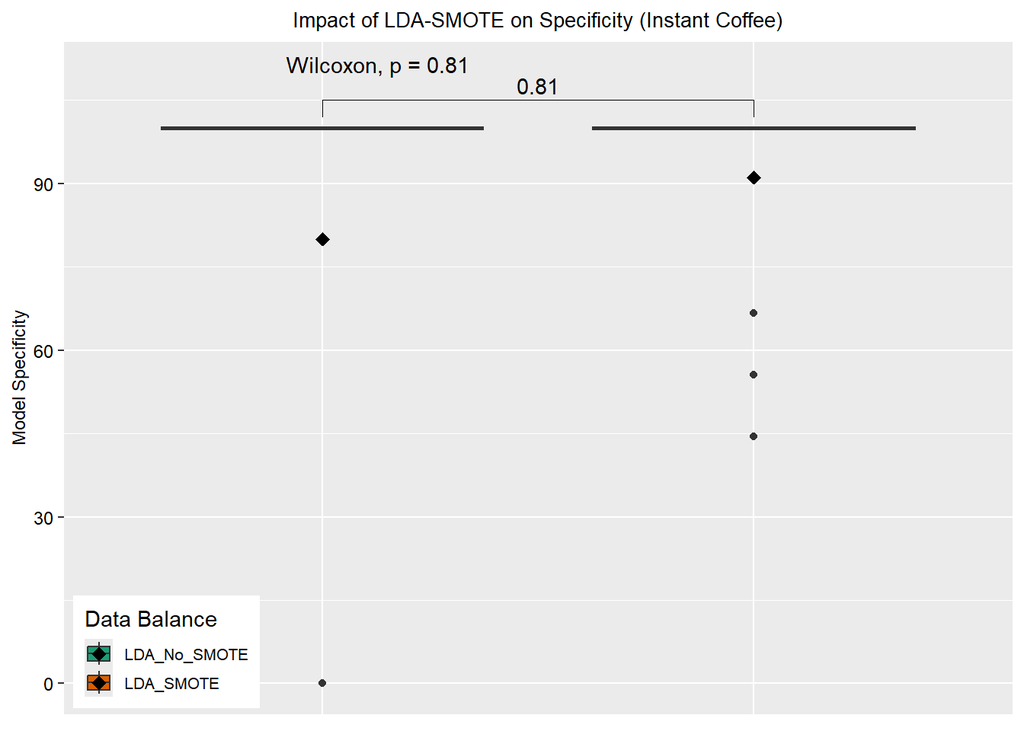

```r
# LDA

lda <- df_bal %>%
  filter(Model %in% c('LDA_No_SMOTE', 'LDA_SMOTE')) %>%
  dplyr::select(Model, MCC, Balanced_Accuracy, Specificity)


# Define statistical comparisons
my_comparisons <- list(c('LDA_No_SMOTE', 'LDA_SMOTE'))

# Create Boxplot

lda %>% ggplot(aes(x = Model, y = Specificity, fill = Model)) +
  geom_boxplot() +
  labs(title = "Impact of LDA-SMOTE on Specificity (Instant Coffee)",
       y = "Model Specificity")+
 theme(
    axis.title.x = element_blank(),
    axis.text.x = element_blank(),
    axis.ticks.x = element_blank(),
    axis.text.y = element_text(color = "black", size = 9),
    axis.title.y = element_text(color = "black", size = 9),
    plot.title = element_text(hjust = 0.5, color = 'black', size = 10),
    legend.position = c(0.01, 0.009),
    legend.justification = c(0, 0),
    legend.backInstant = element_rect(fill = "white", color = "black"),
    legend.key.size = unit(0.5, "cm"),
    legend.text = element_text(size = 8)
  )+
  scale_fill_brewer(palette = "Dark2", name = 'Data Balance')+
  stat_summary(fun=mean, geom="point", shape=18, size=3, color="black")+
  stat_compare_means(comparisons = my_comparisons)+
  stat_compare_means(label.y = max(df_bal$Balanced_Accuracy) * 1.1)
```

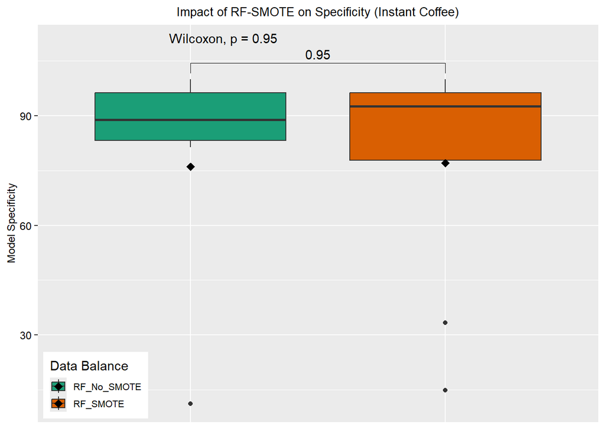

```r
# NNET
rf <- df_bal %>%
  filter(Model %in% c('RF_No_SMOTE', 'RF_SMOTE')) %>%
  dplyr::select(Model, MCC, Balanced_Accuracy, Specificity)


# Define statistical comparisons
my_comparisons <- list(c('RF_No_SMOTE', 'RF_SMOTE'))

# Create Boxplot

rf %>% ggplot(aes(x = Model, y = Specificity, fill = Model)) +
  geom_boxplot() +
  labs(title = "Impact of RF-SMOTE on Specificity (Instant Coffee)",
       y = "Model Specificity")+
 theme(
    axis.title.x = element_blank(),
    axis.text.x = element_blank(),
    axis.ticks.x = element_blank(),
    axis.text.y = element_text(color = "black", size = 9),
    axis.title.y = element_text(color = "black", size = 9),
    plot.title = element_text(hjust = 0.5, color = 'black', size = 10),
    legend.position = c(0.01, 0.009),
    legend.justification = c(0, 0),
    legend.backInstant = element_rect(fill = "white", color = "black"),
    legend.key.size = unit(0.5, "cm"),
    legend.text = element_text(size = 8)
  )+
  scale_fill_brewer(palette = "Dark2", name = 'Data Balance')+
  stat_summary(fun=mean, geom="point", shape=18, size=3, color="black")+
  stat_compare_means(comparisons = my_comparisons)+
  stat_compare_means(label.y = max(df_bal$Balanced_Accuracy) * 1.1)
```

### Check preprocessing and SMOTE

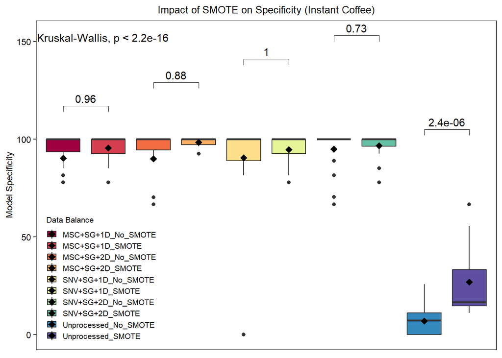

```r
# Define statistical comparisons
my_comparisons <- list(c('Unprocessed_No_SMOTE', 'Unprocessed_SMOTE'),
                       c('MSC+SG+1D_No_SMOTE', 'MSC+SG+1D_SMOTE'),
                       c('MSC+SG+2D_No_SMOTE', 'MSC+SG+2D_SMOTE'),
                       c('SNV+SG+1D_No_SMOTE', 'SNV+SG+1D_SMOTE'),
                       c('SNV+SG+2D_No_SMOTE', 'SNV+SG+2D_SMOTE'))
# Create Box plot

df_bal %>% ggplot(aes(x = Preprocessing, y = Specificity, fill = Preprocessing)) +
  geom_boxplot() +
  labs(title = "Impact of SMOTE on Specificity (Instant Coffee)",
       y = "Model Specificity")+
 theme_bw()+
 theme(
    axis.title.x = element_blank(),
    axis.text.x = element_blank(),
    axis.ticks.x = element_blank(),
    axis.text.y = element_text(color = "black", size = 9),
    axis.title.y = element_text(color = "black", size = 9),
    plot.title = element_text(hjust = 0.5, color = 'black', size = 10),
    panel.grid = element_blank(),
    legend.position = c(0.01, 0.009),
    legend.justification = c(0, 0),
    legend.backInstant = element_rect(fill = "white", color = "black"),
    legend.key.size = unit(0.4, "cm"),
    legend.text = element_text(size = 8),
    legend.title = element_text(size = 8)
  )+
  scale_fill_brewer(palette = "Spectral", name = 'Data Balance')+
  stat_summary(fun=mean, geom="point", shape=18, size=3, color="black")+
  stat_compare_means(comparisons = my_comparisons)+
  stat_compare_means(label.y = max(df_bal$Balanced_Accuracy) * 1.5)
```

```r
ggsave("SMOTE_Data_Preprocessing_Balance_Instant_Coffee_Specifity.png", width = 6, height = 4, dpi = 600, bg = "white")
```

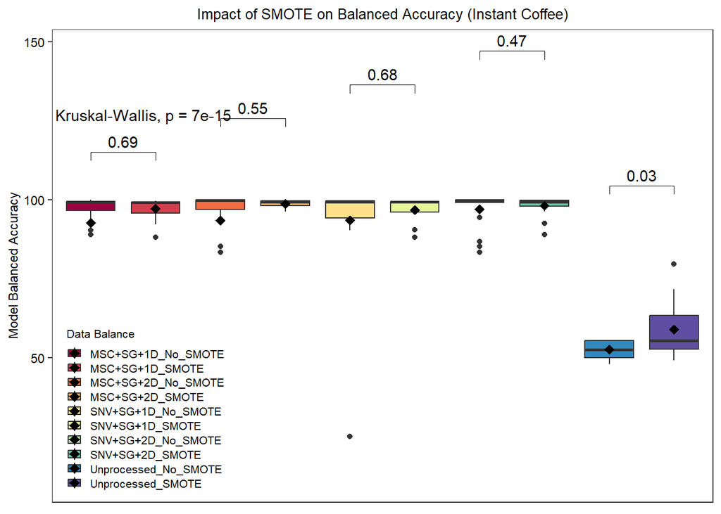

```r
# Define statistical comparisons
my_comparisons <- list(c('Unprocessed_No_SMOTE', 'Unprocessed_SMOTE'),
                       c('MSC+SG+1D_No_SMOTE', 'MSC+SG+1D_SMOTE'),
                       c('MSC+SG+2D_No_SMOTE', 'MSC+SG+2D_SMOTE'),
                       c('SNV+SG+1D_No_SMOTE', 'SNV+SG+1D_SMOTE'),
                       c('SNV+SG+2D_No_SMOTE', 'SNV+SG+2D_SMOTE'))
# Create Box plot

df_bal %>% ggplot(aes(x = Preprocessing, y = Balanced_Accuracy, fill = Preprocessing)) +
  geom_boxplot() +
  labs(title = "Impact of SMOTE on Balanced Accuracy (Instant Coffee)",
       y = "Model Balanced Accuracy")+
  theme_bw()+
 theme(
    axis.title.x = element_blank(),
    axis.text.x = element_blank(),
    axis.ticks.x = element_blank(),
    axis.text.y = element_text(color = "black", size = 9),
    axis.title.y = element_text(color = "black", size = 9),
    plot.title = element_text(hjust = 0.5, color = 'black', size = 10),
    panel.grid = element_blank(),
    legend.position = c(0.01, 0.009),
    legend.justification = c(0,0),
    legend.backInstant = element_rect(fill = "white", color = "black"),
    legend.key.size = unit(0.4, "cm"),
    legend.text = element_text(size = 8),
    legend.title = element_text(size=8),
    legend.spacing.y = unit(0.1,'lines'),
    legend.key.height = unit(0.7,'lines')
  )+
  scale_fill_brewer(palette = "Spectral",name = 'Data Balance')+
  stat_summary(fun=mean, geom="point", shape=18, size=3, color="black")+
  stat_compare_means(comparisons = my_comparisons)+
  stat_compare_means(label.y = max(df_bal$Balanced_Accuracy) * 1.25)
```

```r
ggsave("SMOTE_Data_Preprocessing_Balance_Instant_Coffee_Accuracy.png", width = 6, height = 4, dpi = 600, bg = "white")
```

```r
knn <- df_bal %>%
  filter(Model %in% c('k-NN_No_SMOTE', 'k-NN_SMOTE')) %>%
  dplyr::select(Model, MCC, Balanced_Accuracy, Specificity)
head(knn)
```

```
# A tibble: 6 × 4
  Model           MCC Balanced_Accuracy Specificity
  <fct>         <dbl>             <dbl>       <dbl>
1 k-NN_No_SMOTE -0.01              49.9         0
2 k-NN_No_SMOTE  0.96              99.7       100
3 k-NN_No_SMOTE  1                100         100
4 k-NN_No_SMOTE  0.94              97.9        96.3
5 k-NN_No_SMOTE  1                100         100
6 k-NN_No_SMOTE -0.01              50           0
```

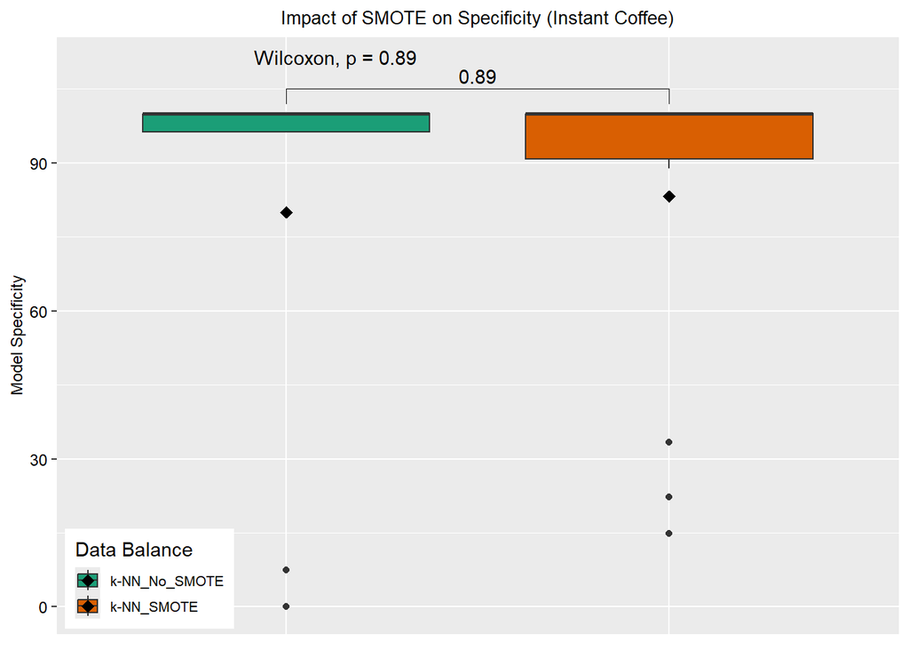

```r
# Define statistical comparisons
my_comparisons <- list(c('k-NN_No_SMOTE', 'k-NN_SMOTE'))

# Create Boxplot

knn %>% ggplot(aes(x = Model, y = Specificity, fill = Model)) +
  geom_boxplot() +
  labs(title = "Impact of SMOTE on Specificity (Instant Coffee)",
       y = "Model Specificity")+
 theme(
    axis.title.x = element_blank(),
    axis.text.x = element_blank(),
    axis.ticks.x = element_blank(),
    axis.text.y = element_text(color = "black", size = 9),
    axis.title.y = element_text(color = "black", size = 9),
    plot.title = element_text(hjust = 0.5, color = 'black', size = 10),
    legend.position = c(0.01, 0.009),
    legend.justification = c(0, 0),
    legend.backInstant = element_rect(fill = "white", color = "black"),
    legend.key.size = unit(0.5, "cm"),
    legend.text = element_text(size = 8)
  )+
  scale_fill_brewer(palette = "Dark2", name = 'Data Balance')+
  stat_summary(fun=mean, geom="point", shape=18, size=3, color="black")+
  stat_compare_means(comparisons = my_comparisons)+
  stat_compare_means(label.y = max(df_bal$Balanced_Accuracy) * 1.1)
```

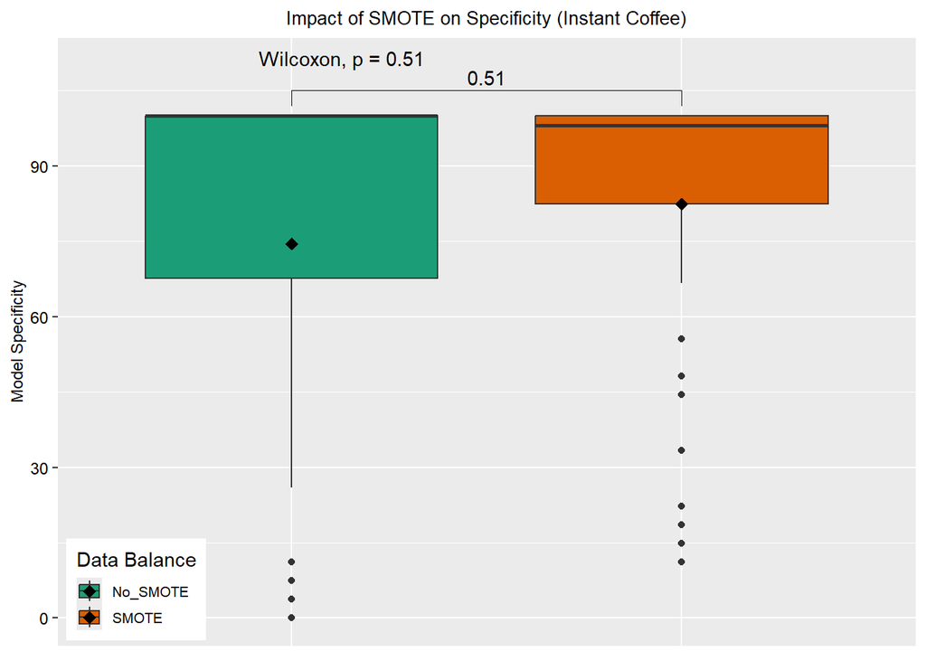

```r
# Define statistical comparisons
my_comparisons <- list(c("No_SMOTE", "SMOTE"))

# Create Boxplot

df_bal %>% ggplot(aes(x = data_balance, y = Specificity, fill = data_balance)) +
  geom_boxplot() +
  labs(title = "Impact of SMOTE on Specificity (Instant Coffee)",
       y = "Model Specificity")+
 theme(
    axis.title.x = element_blank(),
    axis.text.x = element_blank(),
    axis.ticks.x = element_blank(),
    axis.text.y = element_text(color = "black", size = 9),
    axis.title.y = element_text(color = "black", size = 9),
    plot.title = element_text(hjust = 0.5, color = 'black', size = 10),
    legend.position = c(0.01, 0.009),
    legend.justification = c(0, 0),
    legend.backInstant = element_rect(fill = "white", color = "black"),
    legend.key.size = unit(0.5, "cm"),
    legend.text = element_text(size = 8)
  )+
  scale_fill_brewer(palette = "Dark2", name = 'Data Balance')+
  stat_summary(fun=mean, geom="point", shape=18, size=3, color="black")+
  stat_compare_means(comparisons = my_comparisons)+
  stat_compare_means(label.y = max(df_bal$Balanced_Accuracy) * 1.1)
```

```r
#ggsave("SMOTE_Data_Balance_Instant_Coffee.png", width = 6, height = 4, dpi = 600, bg = "white")
```

```r
# Perform the Wilcoxon rank-sum test
# Based on MCC
overall_test <- wilcox.test(df$Unbalanced_Data_MCC, df$Balanced_Data_MCC)

print(overall_test)
```

```
    Wilcoxon rank sum test with continuity correction

data:  df$Unbalanced_Data_MCC and df$Balanced_Data_MCC
W = 4083.5, p-value = 0.9245
alternative hypothesis: true location shift is not equal to 0
```

```r
# Based on Balanced Accuracy
overall_bal_acc <- wilcox.test(df$Imb_Balanced_Accuracy, df$Bal_Balanced_Accuracy)

# Print the results
print(overall_bal_acc)
```

```
    Wilcoxon rank sum test with continuity correction

data:  df$Imb_Balanced_Accuracy and df$Bal_Balanced_Accuracy
W = 4140, p-value = 0.7975
alternative hypothesis: true location shift is not equal to 0
```

- There is no statistical difference in balanced accuracy or MCC between the two groups although models trained with balanced data show improved balanced accuracy when tested on an external data set.

```r
mean_imbalanced <- mean(df$Imb_Balanced_Accuracy)
mean_balanced <- mean(df$Bal_Balanced_Accuracy)

print(paste('The mean balanced accuracy for imbalanced dataset is', round(mean_imbalanced, 2), 'while for the balanced dataset is', round(mean_balanced, 2)))
```

```
[1] "The mean balanced accuracy for imbalanced dataset is 85.85 while for the balanced dataset is 89.97"
```